# Analyzing the Canadian Housing Survey (CHS) for 2022

## Introduction

As noted by Statistics Canada<sup>[1]</sup>, according to the National Housing Strategy Act (NHSA)<sup>[2]</sup>, it is the official housing policy of the Government of Canada to recognize adequate housing as a fundamental human right, essential to individuals' dignity and wellbeing. Consequently, the government is required to develop a long-term housing strategy with the intention of upholding this right and improving outcomes for those in need.

The NHSA is one of many federal initiatives started by the National Housing Strategy (NHS). The NHS, launched in 2017, has allocated `$115+` billion over 10 years towards achieving its stated goals of improving Canada's housing<sup>[3]</sup>. Since Fall 2018, `$62` million over 10 years has been allocated for the collection and analysis of housing needs data. The Canadian Housing Survey (CHS) is one of several surveys created for the purpose of gathering this data, and it focuses on individuals' health and wellbeing as well as the social, financial, economic, and physical circumstances surrounding their housing.

In consideration of this, I have chosen to analyze the CHS 2022 dataset to gain a better understanding of how the economic factors surrounding the ongoing housing crisis relate to the lived experiences of Canadians. Accordingly, I've centred my analysis around the following questions:

- How does economic hardship differ among renters, first-time homebuyers, and others?
- How does core housing need (i.e., failure to satisfy housing adequacy, suitability, or affordability) differ based on shelter cost and income?
- How does general health and mental health differ based on dwelling and neighbourhood issues?
- Are there meaningful clusters that differentiate households based on dwelling satisfaction, dwelling/neighbourhood issues, and well-being?

## Data

The [CHS 2022](https://doi.org/10.25318/46250001-eng) contains survey data for 38,657 private households in Canada across each of the 10 provinces. The data itself provides information on:

- Core Housing Need
- Dwelling Characteristics
- Housing Tenure
- Economic Hardship
- Dwelling & Neighbourhood Satisfaction
- Dwelling & Neighbourhood Issues
- Housing Moves
- Community Engagement
- Demographics
- Wellbeing
- Life & Community Satifaction

Columns in the data correspond to questions in the survey with values being answer categories that respondents' may have chosen. All of the values included, with the exception of columns corresponding to $ amounts, are codes representing the various answer categories.

For instance, the variable EHA_10 corresponds to the question 'In the past 12 months, how difficult or easy was it for your household to meet its financial needs in terms of transportation, housing, food, clothing and other necessary expenses?' and has the follow values with codes on the left and answer categories on the right:

- 1: Very difficult
- 2: Difficult
- 3: Neither difficult nor easy
- 4: Easy
- 5: Very easy
- 9: Not stated

Cleaning this data involved converting these codes to their respective answers to make analysis of the data easier and more understandable. Additionally, I replaced any 'Not stated' values to null to handle them easier during the creation of visualizations.

Code for cleaning is available [here](https://github.com/etrung/CHS2022/blob/main/code/clean.ipynb) and code for visualizations is available [here](https://github.com/etrung/CHS2022/blob/main/code/CHS2022.ipynb).

## How does economic hardship differ among renters, first-time homebuyers, and others?

To see the extent of economic hardship, I chose to examine how these pressures varied across different tenure groups. Accordingly, I chose to group the data into renters, first-time homeowners, existing homeowners, and others who did not fall into these primary categories. This process involved grouping households into renters and homeowners, then subdiving homeowners into first-time homebuyers in the last 5 years (since the survey was taken) and existing homeowners.

First-time homeowners are defined in the dataset as any household that purchased a home in the last 5 years to live in that haven't previously owned a home. Accordingly, existing homeowners are those that had already purchased a home to live in more than 5 years prior to taking the survey.

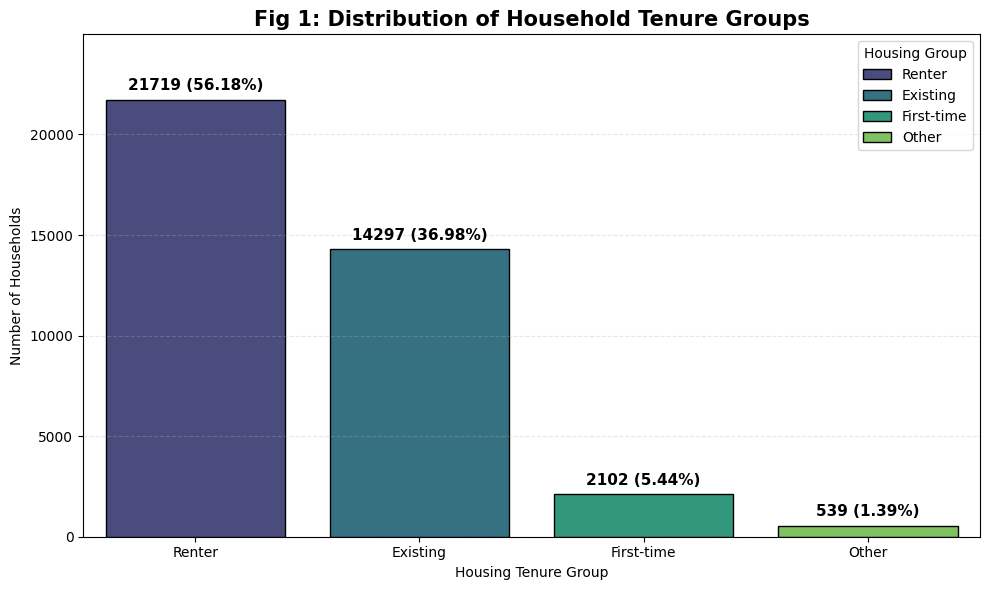

We can see, based on the distribution, that the majority of households that participated in the CHS 2022 were renters. Of the 16399 homeowners, ~87% were existing homeowners and ~13% were first-time owners. Additionally, 1.4% of all households were not captured by these 3 categories.

At 5.44%, the low percentage of first-time homeowners in the data could be indicative of the rising barriers to entry in the housing market, but this can't be concluded decisively without analyzing prior and upcoming CHS data.

It follows from the uneven distribution of tenure groups, that any comparison of resulting patterns or trends should take into account these differences in volume.

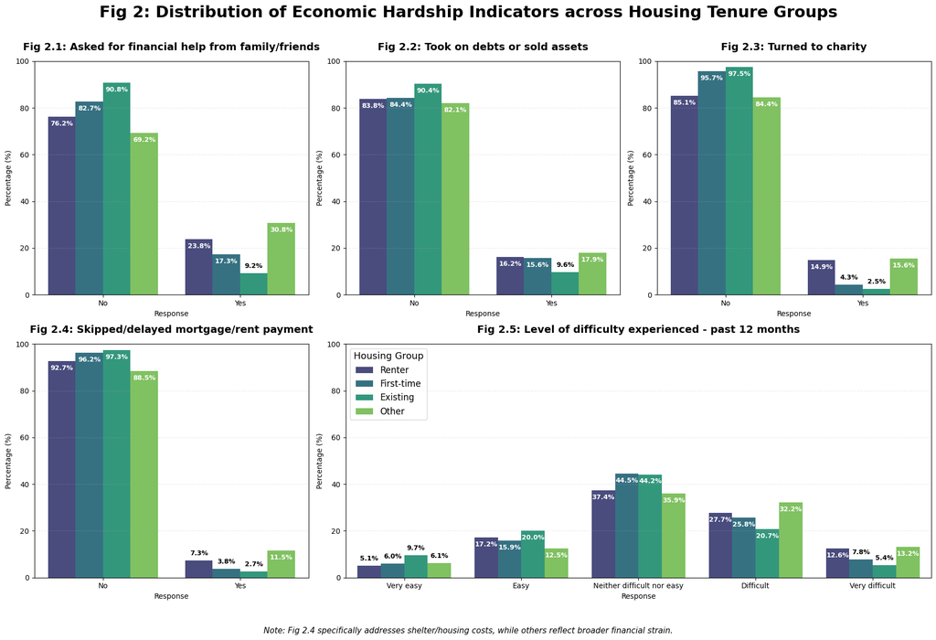

We can see that existing homeowners experience the least amount of economic hardship in all measured areas. Unsurprisingly, those with the ability to afford a home have largely avoided the need to seek financial assistance. Long-term homeownership is indicative of more general financial security which means households in this group are less susceptible to broader economic pressures.

First-time homeowners are similar to existing homeowners in that they do not experience nearly the same amount of financial stress as renters and others, but a sizeable percentage of this group sought assistance from family/friends, and they took on debt or sold assets at a comparable rate to renters. Since the percentage of first-timers that have skipped/missed housing payments is still much lower than those in the 'Renter' and 'Other' categories, this might indicate that the economic struggles experienced group are not directly tied to housing. Though, it could be the case that prioritization of housing payments makes them more likely to seek assistance for other expenses.

Among the primary tenure groups, renters were most likely to experience higher levels of difficulty meeting necessary costs as well as being more likely to require financial assistance. This might be explained by renters being more directly exposed to the fluctuating state of the housing market, which might result in things like unpredictable rent hikes, as opposed to homeowners whose situations may be more stable as a result of things like fixed-rate mortgages.

For households in the 'Other' category, they disproportionately experience much higher rates of economic hardship than any of the primary tenure groups.

**Fig 3:** Sensitivity Analysis of Housing Tenure Group Redistribution

| Indicator | Tenure Group Category | Renter Base (%) | Renter Adjusted (%) | Renter Net (%) | First-time Base (%) | First-time Adjusted (%) | First-time Net (%) | Existing Base (%) | Existing Adjusted (%) | Existing Net (%) |
| --- | --- | --- | --- | --- | --- | --- | --- | --- | --- | --- |
| Asked for financial help from family/friends | No | 76.23 | 76.06 | -0.17 | 82.70 | 79.95 | -2.76 | 90.80 | 90.02 | -0.79 |
|  | Yes | 23.77 | 23.94 | 0.17 | 17.30 | 20.05 | 2.76 | 9.20 | 9.98 | 0.79 |
| Took on debts or sold assets | No | 83.84 | 83.80 | -0.04 | 84.37 | 83.91 | -0.46 | 90.37 | 90.07 | -0.30 |
|  | Yes | 16.16 | 16.20 | 0.04 | 15.63 | 16.09 | 0.46 | 9.63 | 9.93 | 0.30 |
| Turned to charity | No | 85.11 | 85.09 | -0.02 | 95.73 | 93.45 | -2.28 | 97.51 | 97.04 | -0.47 |
|  | Yes | 14.89 | 14.91 | 0.02 | 4.27 | 6.55 | 2.28 | 2.49 | 2.96 | 0.47 |
| Skipped/delayed mortgage/rent payment | No | 92.68 | 92.58 | -0.10 | 96.19 | 94.62 | -1.58 | 97.32 | 97.00 | -0.32 |
|  | Yes | 7.32 | 7.42 | 0.10 | 3.81 | 5.38 | 1.58 | 2.68 | 3.00 | 0.32 |
| Level of difficulty experienced - past 12 months | Very easy | 5.13 | 5.16 | 0.02 | 6.01 | 6.03 | 0.03 | 9.67 | 9.55 | -0.13 |
|  | Easy | 17.23 | 17.12 | -0.12 | 15.87 | 15.18 | -0.69 | 20.01 | 19.74 | -0.27 |
|  | Neither difficult nor easy | 37.37 | 37.33 | -0.03 | 44.52 | 42.77 | -1.75 | 44.17 | 43.87 | -0.30 |
|  | Difficult | 27.68 | 27.79 | 0.11 | 25.79 | 27.10 | 1.31 | 20.73 | 21.14 | 0.42 |
|  | Very difficult | 12.58 | 12.60 | 0.02 | 7.82 | 8.92 | 1.10 | 5.41 | 5.70 | 0.28 |

To account for the data in the 'Other' category, I performed a sensitivity analysis using the following formula to check how the results might change if the 'Other' population was fully added into each of the primary tenure groups.

$adjusted percentage = (count of target group response + count of other response) / (target group population + other population)$

Given the distribution of tenure groups shown in Fig 1, the results are not particularly surprising.

On account of their large populations, net change in percentages for renters and existing owners is fairly insignificant, with none of the categories changing by even a single percentage point. By contrast, percentages for first-timers were the most sensitive to the change which is to be expected since combining their popultion with 'Other' would increase it by over 20%.

Overall, even under the assumptions of this test, renters still stand as the most economically strained group with first-time owners ranking second and existing owners ranking third.

## How does core housing need differ based on shelter cost and income?

Core housing need in the CHS is defined as the failure to satisfy at least one of the established standards for housing adequacy, suitability, and affordability, and if income before taxes is at or below the community-and-bedroom specific income threshold. The population for this category excludes any households on reserves, farm dwellings, and households with negative or zero total household income before-tax or a shelter-to-income ratio greater than or equal to 100%.

In the data, the three standards that determine core housing need are defined as follows<sup>[4]</sup>:

- Adequacy: reported by residents as not requiring major repairs
- Suitability: enough bedrooms for the size and composition of resident households according to the National Occupancy Standard (NOS), conceived by the Canada Mortgage and Housing Corporation and provincial and territorial representatives
- Affordability: shelter costs equal to or less than 30% of total before-tax household income

In attempting to answer this question, the hope is to see if the majority of those in core housing need are so because of affordability reasons as opposed to housing adequacy or suitability.

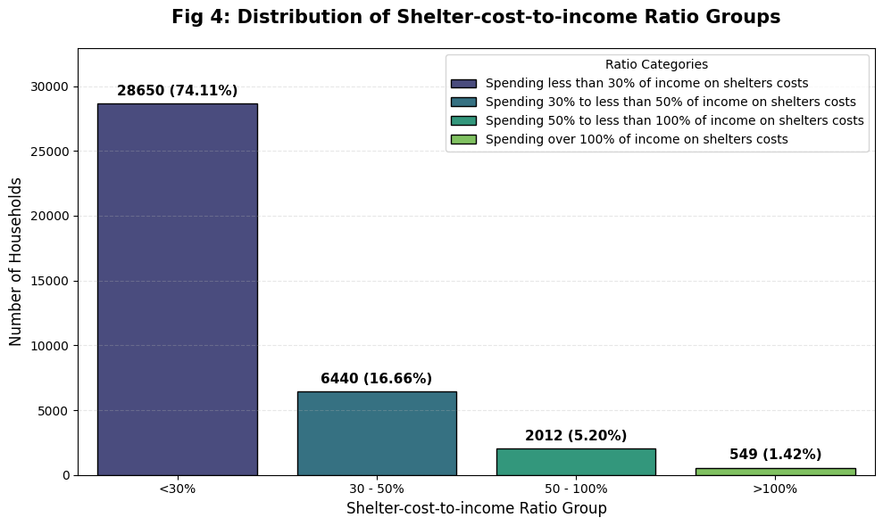

We can see that around 21.86% of households spend 30% to less than 100% of income on shelter costs. Given that affordability is one of the factors that determine core housing need, this places an upper bound on households in core housing need for financial reasons at 8452. Since core housing need does not include all households, we can expect the actual number to be lower than this.

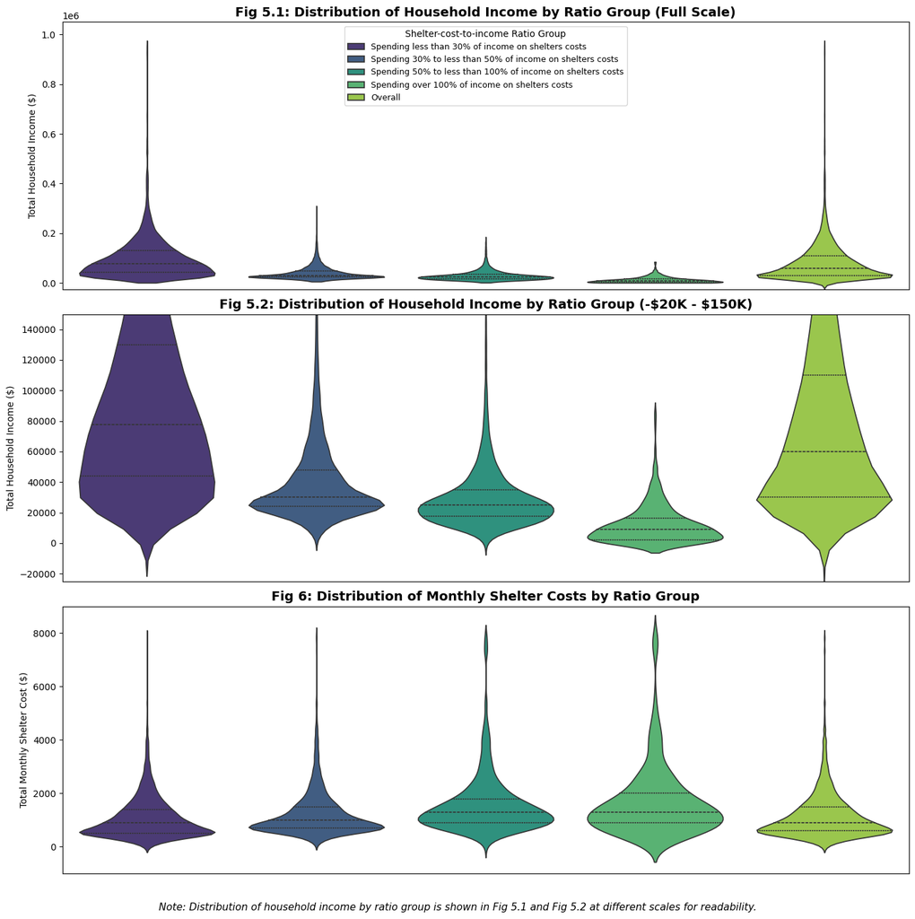

Based on the plots, there seems to be an inverse relationship between total income and shelter cost across the ratio groups. Moving up tiers in percentage of income spent on shelter costs seems to indicate lower total household incomes as well as higher total monthly shelter costs. This tracks with medians and modes of each group and is to be expected since the shelter-to-income ratio is itself a function of these two variables.

**Fig 7:** Household Income, Shelter Costs, and Core Housing Need Prevalence by Ratio Group

| Shelter-cost-to-income ratio | Household Income ($) Min Income | Household Income ($) Q1 (25%) | Household Income ($) Median | Household Income ($) Q3 (75%) | Household Income ($) Max Income | Monthly Shelter Costs ($) Min Cost | Monthly Shelter Costs ($) Q1 (25%) | Monthly Shelter Costs ($) Median | Monthly Shelter Costs ($) Q3 (75%) | Monthly Shelter Costs ($) Max Cost | Core Housing Need (%) In core housing need | Core Housing Need (%) Not in core housing need |
| --- | --- | --- | --- | --- | --- | --- | --- | --- | --- | --- | --- | --- |
| Spending less than 30% of income on shelters costs | 900.0 | 44000.0 | 77500.0 | 130000.0 | 975000.0 | 0.0 | 500.0 | 900.0 | 1400.0 | 7900.0 | 2.764 | 97.236 |
| Spending 30% to less than 50% of income on shelters costs | 5500.0 | 24000.0 | 30000.0 | 48000.0 | 310000.0 | 200.0 | 700.0 | 1000.0 | 1500.0 | 7900.0 | 59.363 | 40.637 |
| Spending 50% to less than 100% of income on shelters costs | 1500.0 | 17500.0 | 25000.0 | 35000.0 | 185000.0 | 100.0 | 900.0 | 1300.0 | 1800.0 | 7800.0 | 76.988 | 23.012 |
| Spending over 100% of income on shelters costs | 800.0 | 2100.0 | 9000.0 | 16500.0 | 85000.0 | 200.0 | 900.0 | 1300.0 | 2000.0 | 7900.0 | NaN | NaN |
| Overall | -72500.0 | 30000.0 | 60000.0 | 110000.0 | 975000.0 | 0.0 | 600.0 | 900.0 | 1500.0 | 7900.0 | 15.945 | 80.032 |

Most households are not in core housing need according to Fig 7, meaning ~80% of households either satisfy all three acceptable housing criteria, are below community-and-bedroom specific income thresholds, or simply belong to one of the excluded housing categories described above.

We can see that core housing need concentrates disproportionately in the households belonging to the 30-50% and 50-100% ratio groups. Based on the numbers shown in Fig 4, this means that ~87% of the 6164 households in core housing need spend between 30-100% of total household income on shelter costs. Again, this is to be expected based on the definition of affordability used, but it seems to indicate that the largest barriers to acceptable housing for Canadians are low income and high costs.

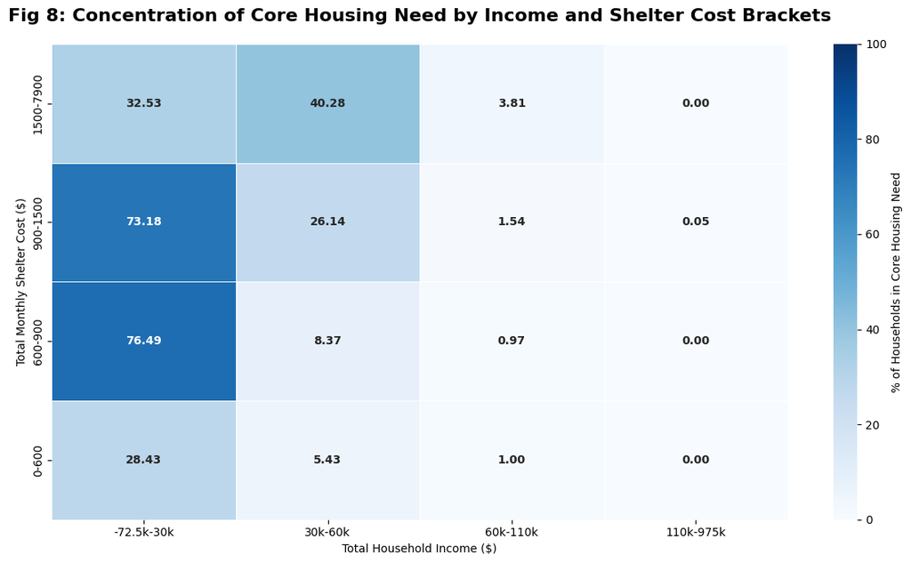

Based on Fig 7 and Fig 8, we can see that households in core housing need concentrate at the lower end of total household income. This confirms that access to acceptable housing is significantly more difficult to achieve for low-income earners, specifically those in the lowest income bracket with positive incomes. As income increases beyond the median of `$60k`, the percentage of households in core housing need drops to single-digit percentages with incomes beyond `$110k` having near-zero percentages for every shelter cost bracket. Overall, it seems that lack of access to cheaper housing options forces low-income Canadians into dwellings with core housing needs.

## How does general health and mental health differ based on dwelling and neighbourhood issues?

Examining the intersection of environmental living conditions and respondents' self-reported health will hopefully give a picture of the relationship between quality of housing and life. To the extent that housing conditions are themselves determined by economic and financial factors, any relationship found between household environment and wellbeing will likely reinforce the socio-economic patterns suggested by the previous questions.

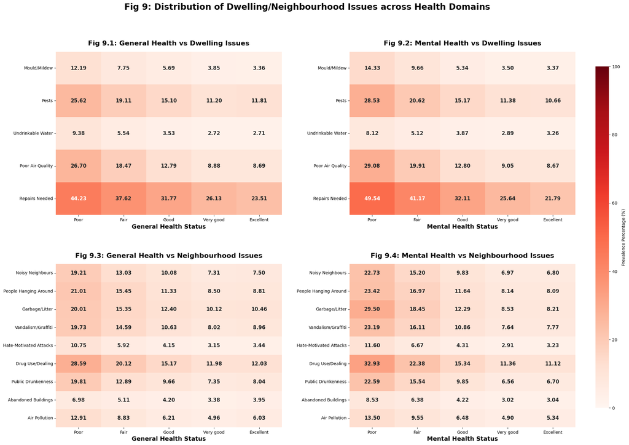

Across the board, those who reported 'Poor' health and mental health are more likely to report issues in their dwelling and neighbourhood. Across all health and mental health categories, repair needed and drug use/dealing are the most common dwelling and neighbourhood issues, respectively.

The connection between poor health and mental health outcomes and environmental issues, while notable, may not be indicative of any strong relationship or causality. Individuals with poorer wellbeing may be more likely to perceive or report these issues as being more severe than those with better health in an instance of reporting bias. Regardless, there is a pattern shown here between poor health outcomes and the presence of dwelling and neighbourhood issues.

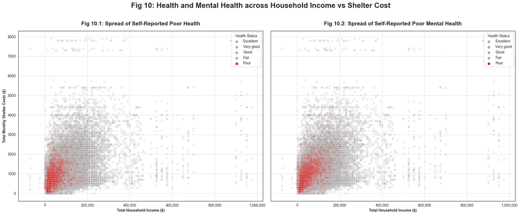

We can see that the spread of poor health and mental health concentrate most strongly at lower amounts of household income and shelter costs. This, however, seems to track with the general distribution of the population. As seen in Fig 7, the bottom 50% of the CHS 2022 households have a total income between `-$75,000` and `$60,000` and total monthly shelter costs between `$0` and `$900`. This area seems to align with the location of poor health and mental health markers in the scatterplots. Though, the connection between health and low-incomes likely extends beyond the context of just housing.

## Are there meaningful groups that differentiate households based on dwelling satisfaction, dwelling/neighbourhood issues, and well-being?

This question was chosen to further evaluate the relationship between 'subjective' quality-of-life and 'objective' economic/financial factors.

To get the clusters, I used MCA to handle the categorical nature of the variables and used K-Means to cluster the households accordingly. Afterwards, I used bar charts to see the distribution of each cluster across tenure groups, shelter-to-income ratio groups, core housing need, skipped/delayed mortgage/rent payments, total household income, and total monthly shelter costs.

To avoid skewing the clusters too heavily with dwelling and neighbourhood issues (since the prevalence of these issues was fairly low across the board), I decided to select the most prevalent issues in the data which were repairs needed and drug use/dealing as seen in Fig 9.

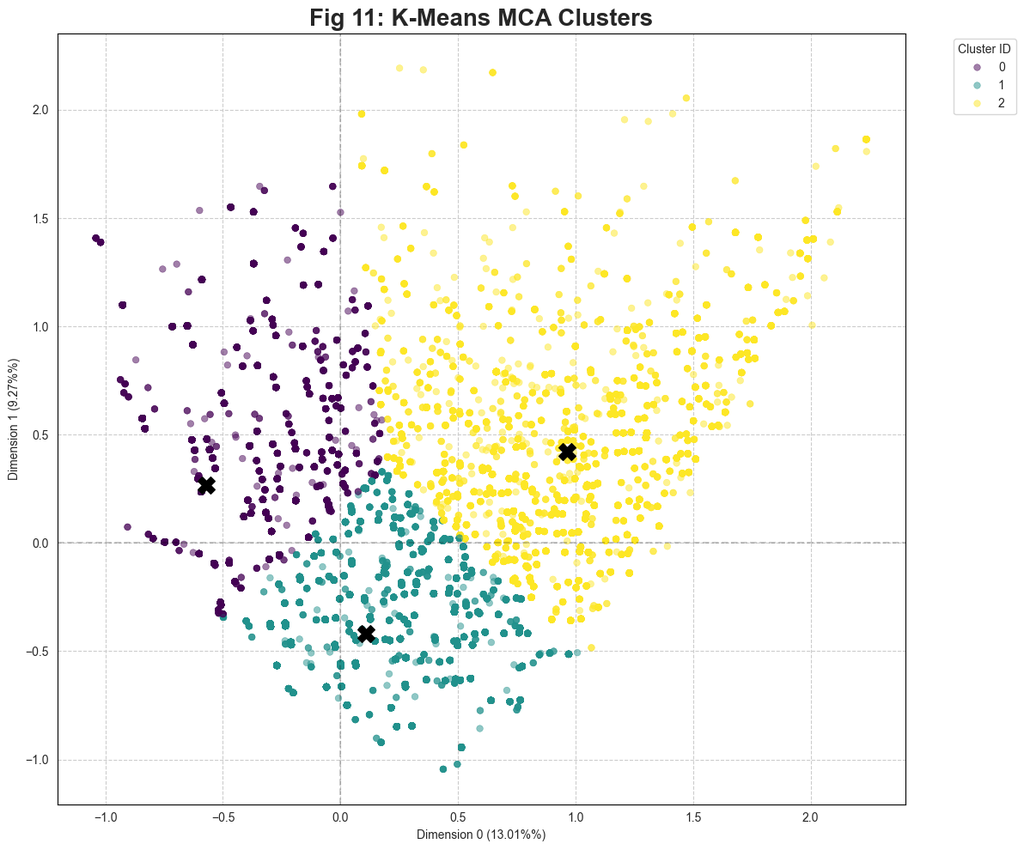

[figure not shown]

For the categories checked, the clusters seem to identify three separate categories that correspond to varying tiers of socioeconomic stability.

For many of the indicators, Cluster 1 (Average) more or less tracks with the percentages shown for the overall population. Accordingly, Cluster 1 represents a baseline of households which are neither protected from market pressures nor acutely vulnerable to them.

Cluster 2 (At-risk) identifies a higher vulnerability group of mostly renters who are disproportionately affected by core housing need, high spending on shelter costs by income, and are more than two times as likely to skip or delay mortgage/rent payments compared to the general population. These households experience a higher degree of economic hardship than the other clusters despite having the lowest percentage of high shelter cost housing.

The clustering analysis seems to confirm that there is a relationship between subjective indicators of wellbeing and the objective material realities of housing affordability and financial struggles.

## Conclusion

The material and economic realities of the housing market seem to have a determinant effect on the physical and mental wellbeing of Canadians. There is a measurable decline in health and financial security as shelter costs consume larger proportions of household income. This means that the inability to provide more low-cost housing options for low-income earners seems to contribute to poorer outcomes in their quality of life. The added stress of financial insecurity from housing issues can only be deleterious on the long-term physical and mental healths of those in lower income brackets.

Ultimately, the broader goals of the NHS in improving outcomes for at-risk groups remain out of reach without significant investment into establishing a solid foundation of affordable housing and increases in wage proportional to increases in shelter costs.

## Acknowledgements

This analysis was inspired by William Spackman's [Calgary Shared Mobility Pilot Trips Analysis](https://reservoir-jogs.github.io/notebook/YYC-Scooters.html).

## Source Data

Statistics Canada. *Canadian Housing Survey*: Public use of microdata file, 2022.

DOI: https://doi.org/10.25318/46250001-eng

## References

[1] https://www150.statcan.gc.ca/n1/daily-quotidien/241119/dq241119b-eng.htm

[2] https://laws-lois.justice.gc.ca/eng/acts/N-11.2

[3] https://housing-infrastructure.canada.ca/housing-logement/ptch-csd/reports-rapports/prog-nhs-sept-2025-sept-snl-eng.html

[4] https://www.statcan.gc.ca/hub-carrefour/quality-life-qualite-vie/prosperity-prosperite/acceptable-housing-logement-acceptable-eng.htm